# proj_mock

## Wstęp

Celem projektu jest zbadanie jak zmieniało się nastawienie globalnej społeczności do Chin oraz USA na przestrzeni ostatnich 10 lat (tzn. od 2013 do 2023 roku). Do analizy sentymentu zostały wykorzystane tweety pozyskane za pomocą narzędzia snscrape. Każde państwo zostało przeanalizowane na podstawie ok. 96 000 tweetów pozyskanych za pomocą hashtagów #america oraz #china.

```python
import re
import pandas as pd
import snscrape.modules.twitter as sntwitter
import nltk
nltk.download("all")
from nltk.corpus import stopwords
from nltk.tokenize import word_tokenize
from nltk.stem import WordNetLemmatizer
from wordcloud import WordCloud
from nltk.sentiment.vader import SentimentIntensityAnalyzer
import matplotlib.pyplot as plt
```

### Scraping #China

```python
# Setting variables to be used below
maxTweets = 800
year_start = 2013
year_end = 2023

# Creating list to append tweet data
china_tweets_list = []

# Loop over each year
for year in range(year_start, year_end):
    # Loop over each month
    for month in range(1, 13):
        if month == 12:
            query = f'#China since:{year}-{month}-02 until:{year+1}-01-01 lang:en'
        else:
            query = f'#China since:{year}-{month}-02 until:{year}-{month+1}-01 lang:en'

        # Using TwitterSearchScraper to scrape data and append tweets to list
        for i, tweet in enumerate(sntwitter.TwitterSearchScraper(query).get_items()):
            if i >= maxTweets:  # We use 'greater than or equal to' as indices start at 0
                break
            china_tweets_list.append([tweet.date, re.sub(r"http\S+", "", tweet.rawContent)])

# Creating a dataframe from the tweets list above
china_tweets_df = pd.DataFrame(china_tweets_list, columns=['Datetime', 'Content'])

china_tweets_df.to_csv('china_tweets.csv', index=False)
```

### Scraping #Usa

```python
# Setting variables to be used below
maxTweets = 800
year_start = 2013
year_end = 2023

# Creating list to append tweet data
usa_tweets_list = []

# Loop over each year
for year in range(year_start, year_end):
    # Loop over each month
    for month in range(1, 13):
        if month == 12:
            query = f'(#theus OR #america) since:{year}-{month}-02 until:{year+1}-01-01 lang:en'
        else:
            query = f'(#theus OR #america) since:{year}-{month}-02 until:{year}-{month+1}-01 lang:en'

        # Using TwitterSearchScraper to scrape data and append tweets to list
        for i, tweet in enumerate(sntwitter.TwitterSearchScraper(query).get_items()):
            if i >= maxTweets:  # We use 'greater than or equal to' as indices start at 0
                break
            usa_tweets_list.append([tweet.date, re.sub(r"http\S+", "", tweet.rawContent)])

# Creating a dataframe from the tweets list above
usa_tweets_df = pd.DataFrame(usa_tweets_list, columns=['Datetime', 'Content'])

usa_tweets_df.to_csv('usa_tweets.csv', index=False)
```

[output not shown]

[output cut: 228 more lines]

[output not shown]

## Analiza Sentymentu

#### NLTK Vader

```python
# create preprocess_text function
def preprocess_text(text):
    str_processed = re.sub(r'\s+', ' ', text.lower().strip())

    # Tokenize the text
    tokens = word_tokenize(str_processed)

    # Remove stop words
    stop_words = stopwords.words('english')
    stop_words.extend(['https', 'http', 'co', 'amp', 'rt', '#', '@'])
    filtered_tokens = [token for token in tokens if token not in stop_words]

    # Lemmatize the tokens
    lemmatizer = WordNetLemmatizer()
    lemmatized_tokens = [lemmatizer.lemmatize(token) for token in filtered_tokens]

    # Join the tokens back into a string
    processed_text = ' '.join(lemmatized_tokens)

    return processed_text
```

```python
china_tweets_df = pd.read_csv('china_tweets.csv')
china_tweets_df['Content'] = china_tweets_df['Content'].astype(str)
china_tweets_df['Content'] = china_tweets_df['Content'].apply(preprocess_text)
```

```python
usa_tweets_df = pd.read_csv('usa_tweets.csv')
usa_tweets_df['Content'] = usa_tweets_df['Content'].astype(str)
usa_tweets_df['Content'] = usa_tweets_df['Content'].apply(preprocess_text)
```

```python
def get_sentiment(text):

    def polarity_score(compound):
        if compound >= 0.05:
            return "positive"
        elif compound <= -0.05:
            return "negative"
        elif compound > -0.05 and compound < 0.05:
            return "neutral"

    analyzer = SentimentIntensityAnalyzer()
    scores = analyzer.polarity_scores(text)
    compound = scores['compound']
    return polarity_score(compound)
```

```python
china_tweets_df['Sentiment'] = china_tweets_df['Content'].apply(get_sentiment)
```

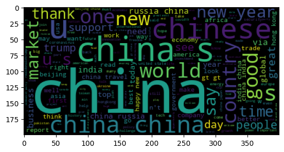

```python
positive_tweets = china_tweets_df[china_tweets_df['Sentiment'] == 'positive']
wordcloud = WordCloud().generate(' '.join(positive_tweets['Content']))
plt.imshow(wordcloud);
```

#### Chiny i charakterystyczne słowa dla pozytywnych tweetów:

- new year
- travel
- market
- business
- trade
- world

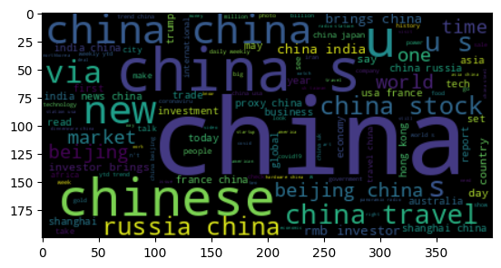

```python
neutral_tweets = china_tweets_df[china_tweets_df['Sentiment'] == 'neutral']
wordcloud = WordCloud().generate(' '.join(neutral_tweets['Content']))
plt.imshow(wordcloud, interpolation='bilinear');
```

#### Chiny i charakterystyczne słowa dla neutralnych tweetów:

- market
- china travel
- beijing
- investor
- russia

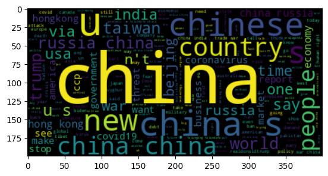

```python
negative_tweets = china_tweets_df[china_tweets_df['Sentiment'] == 'negative']
wordcloud = WordCloud().generate(' '.join(negative_tweets['Content']))
plt.imshow(wordcloud, interpolation='bilinear');
```

#### Chiny i charakterystyczne słowa dla negatywnych tweetów:

- taiwan
- usa
- coronavirus
- hongkong
- war
- covid
- ccp

```python
usa_tweets_df['Sentiment'] = usa_tweets_df['Content'].apply(get_sentiment)
```

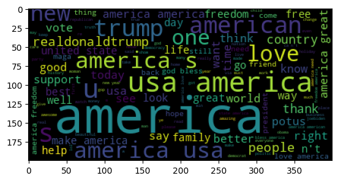

```python
positive_tweets = usa_tweets_df[usa_tweets_df['Sentiment'] == 'positive']
wordcloud = WordCloud().generate(' '.join(positive_tweets['Content']))
plt.imshow(wordcloud);
```

#### USA i charakterystyczne słowa dla pozytywnych tweetów:

- freedom
- trump
- vote
- support
- family

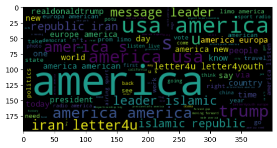

```python
neutral_tweets = usa_tweets_df[usa_tweets_df['Sentiment'] == 'neutral']
wordcloud = WordCloud().generate(' '.join(neutral_tweets['Content']))
plt.imshow(wordcloud, interpolation='bilinear');
```

#### USA i charakterystyczne słowa dla neutralnych tweetów:

- trump
- message
- leader
- islamic
- europe

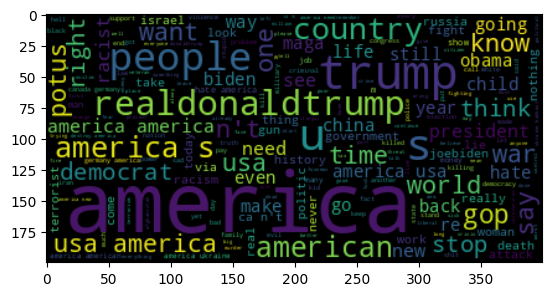

```python
negative_tweets = usa_tweets_df[usa_tweets_df['Sentiment'] == 'negative']
wordcloud = WordCloud().generate(' '.join(negative_tweets['Content']))
plt.imshow(wordcloud, interpolation='bilinear');
```

#### USA i charakterystyczne słowa dla negatywnych tweetów:

- trump
- obama
- biden
- democrat
- president
- maga
- racist

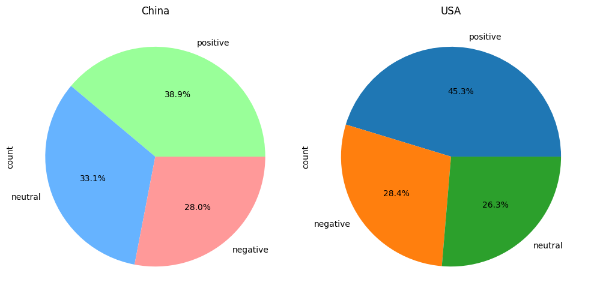

```python
fig, ax = plt.subplots(1, 2, figsize=(10, 5))  # 1 row, 2 columns

china_tweets_df.value_counts('Sentiment').plot.pie(autopct='%1.1f%%', ax=ax[0], colors=['#99ff99','#66b3ff','#ff9999']);
ax[0].set_title('China')

usa_tweets_df.value_counts('Sentiment').plot.pie(autopct='%1.1f%%', ax=ax[1]);
ax[1].set_title('USA')

plt.tight_layout()
plt.show()
```

### Wnioski:

- USA miało więcej pozytywnych tweetów
- liczba negatywnych tweetów była taka sama dla obu krajów
- Chiny miały więcej neutralnych tweetów

## BERT

```python
from transformers import pipeline

# create a sentiment analysis pipeline
nlp = pipeline("sentiment-analysis", device=0) # < 0 means CPU, >= 0 means GPU

# classify some text
def bert_sentiment(text):
    result = nlp(text)[0]
    sentiment = result['label']
    return sentiment
```

```
No model was supplied, defaulted to distilbert-base-uncased-finetuned-sst-2-english and revision af0f99b (https://huggingface.co/distilbert-base-uncased-finetuned-sst-2-english).
Using a pipeline without specifying a model name and revision in production is not recommended.
```

```python
china_tweets_df['Bert_Sentiment'] = china_tweets_df['Content'].apply(bert_sentiment)
```

```python
usa_tweets_df['Bert_Sentiment'] = usa_tweets_df['Content'].apply(bert_sentiment)
```

```python
china_tweets_df.to_csv('china_tweets_sentiment.csv', index=False)
```

```python
usa_tweets_df.to_csv('usa_tweets_sentiment.csv', index=False)
```

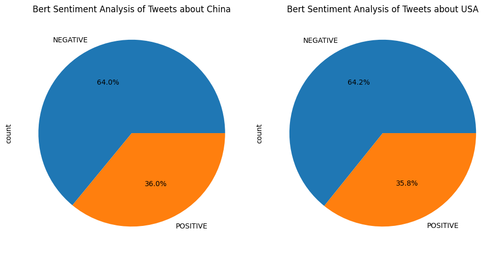

```python
fig, ax = plt.subplots(1, 2, figsize=(10, 5))  # 1 row, 2 columns

china_tweets_df.value_counts('Bert_Sentiment').plot.pie(autopct='%1.1f%%', ax=ax[0]);
ax[0].set_title('Bert Sentiment Analysis of Tweets about China')

usa_tweets_df.value_counts('Bert_Sentiment').plot.pie(autopct='%1.1f%%', ax=ax[1]);
ax[1].set_title('Bert Sentiment Analysis of Tweets about USA')

plt.tight_layout()
plt.show()
```

### Analiza Czasowa

```python
def time_series_anlysis_bar_chart(df):
    copy_df = df.copy()
    copy_df['Datetime'] = pd.to_datetime(copy_df['Datetime'], errors='coerce')
    copy_df = copy_df.dropna()
    copy_df['Year'] = copy_df['Datetime'].dt.year

    sentiment_yearly = copy_df.groupby('Year')['Sentiment'].value_counts().unstack().fillna(0)
    bert_sentiment_yearly = copy_df.groupby('Year')['Bert_Sentiment'].value_counts().unstack().fillna(0)

    fig, ax = plt.subplots(2, 1, figsize=(10, 10))

    sentiment_yearly.plot(kind='bar', stacked=True, ax=ax[0])
    ax[0].set_title('Yearly Sentiment Distribution')
    ax[0].set_ylabel('Count')

    bert_sentiment_yearly.plot(kind='bar', stacked=True, ax=ax[1])
    ax[1].set_title('Yearly Bert Sentiment Distribution')
    ax[1].set_ylabel('Count')

    plt.tight_layout()
    plt.show()

def time_series_analysis_line_chart(df):
    copy_df = df.copy()
    copy_df['Datetime'] = pd.to_datetime(copy_df['Datetime'], errors='coerce')
    copy_df = copy_df.dropna()
    copy_df['Year'] = copy_df['Datetime'].dt.year

    sentiment_yearly = copy_df.groupby('Year')['Sentiment'].value_counts().unstack().fillna(0)
    bert_sentiment_yearly = copy_df.groupby('Year')['Bert_Sentiment'].value_counts().unstack().fillna(0)

    fig, ax = plt.subplots(2, 1, figsize=(10, 10))

    sentiment_yearly.plot(kind='line', ax=ax[0])
    ax[0].set_title('Yearly Sentiment Distribution')
    ax[0].set_ylabel('Count')
    ax[0].grid(True)

    bert_sentiment_yearly.plot(kind='line', ax=ax[1])
    ax[1].set_title('Yearly Bert Sentiment Distribution')
    ax[1].set_ylabel('Count')
    ax[1].grid(True)

    plt.tight_layout()
    plt.show()
```

### Chiny analiza czasowa

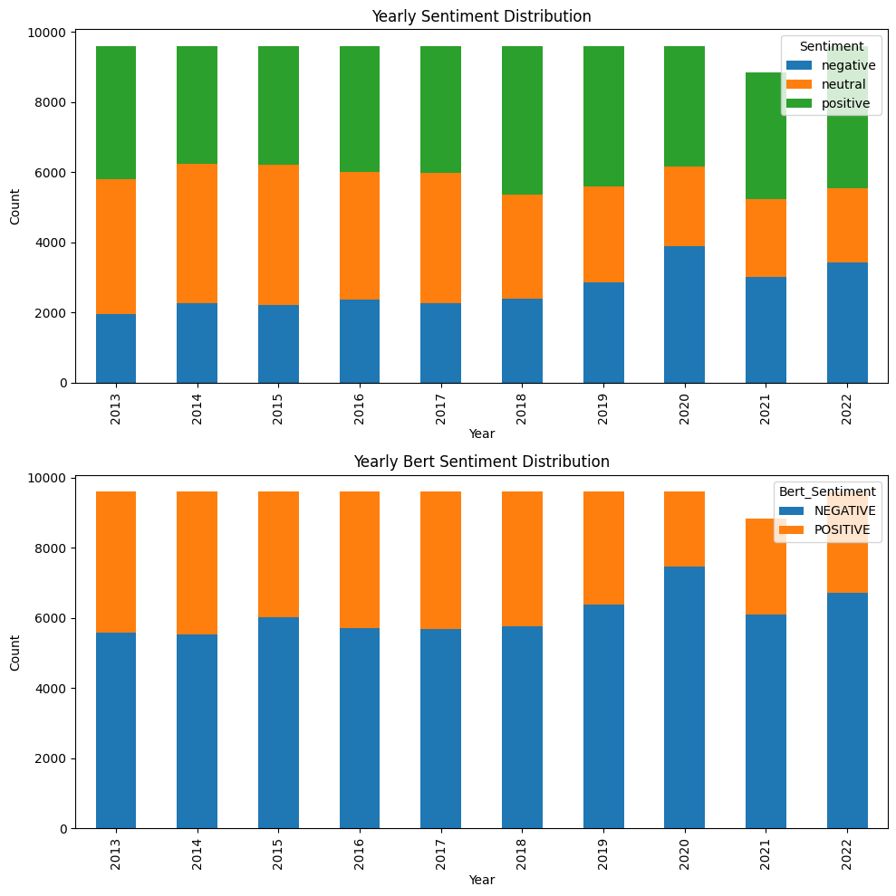

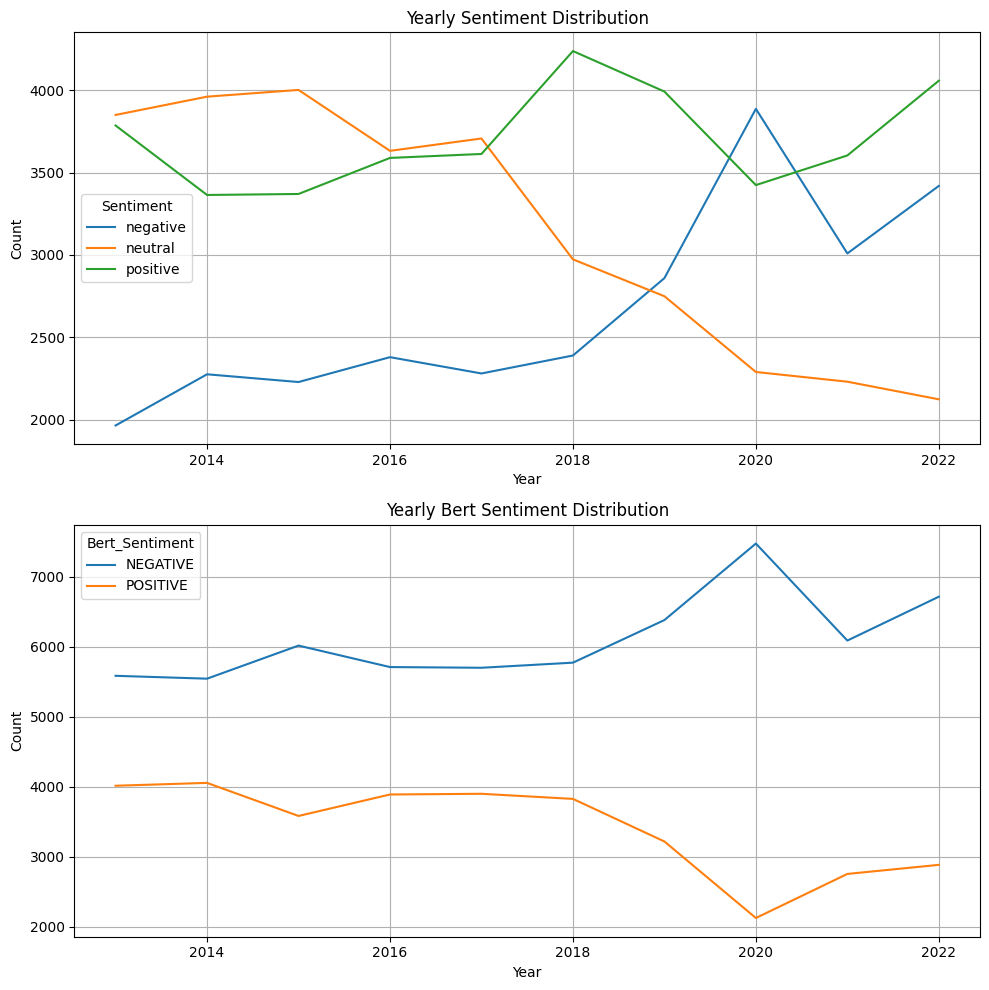

```python
time_series_anlysis_bar_chart(china_tweets_df)
time_series_analysis_line_chart(china_tweets_df)
```

### USA analiza czasowa

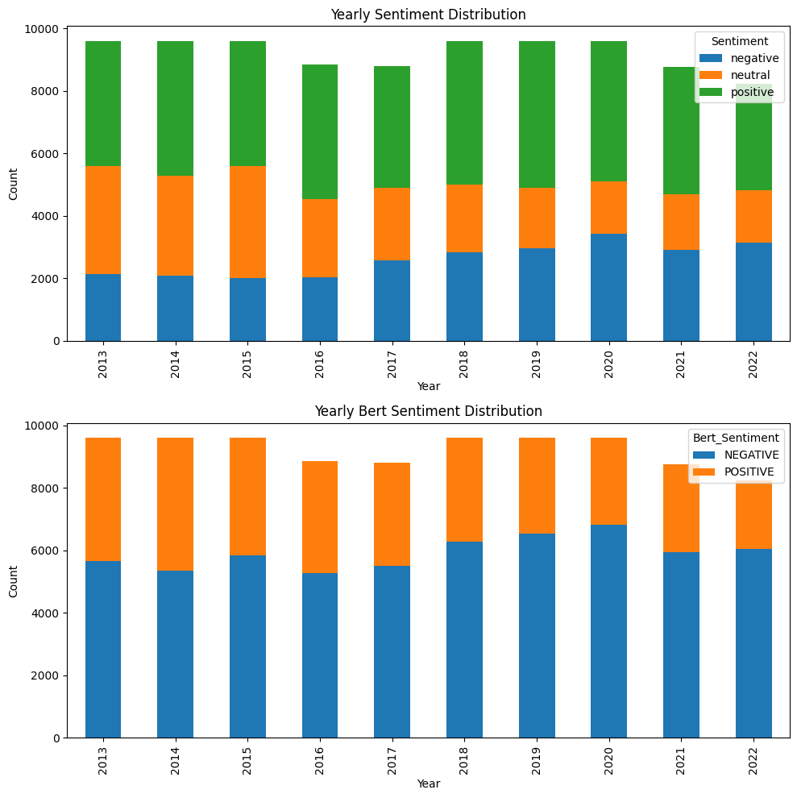

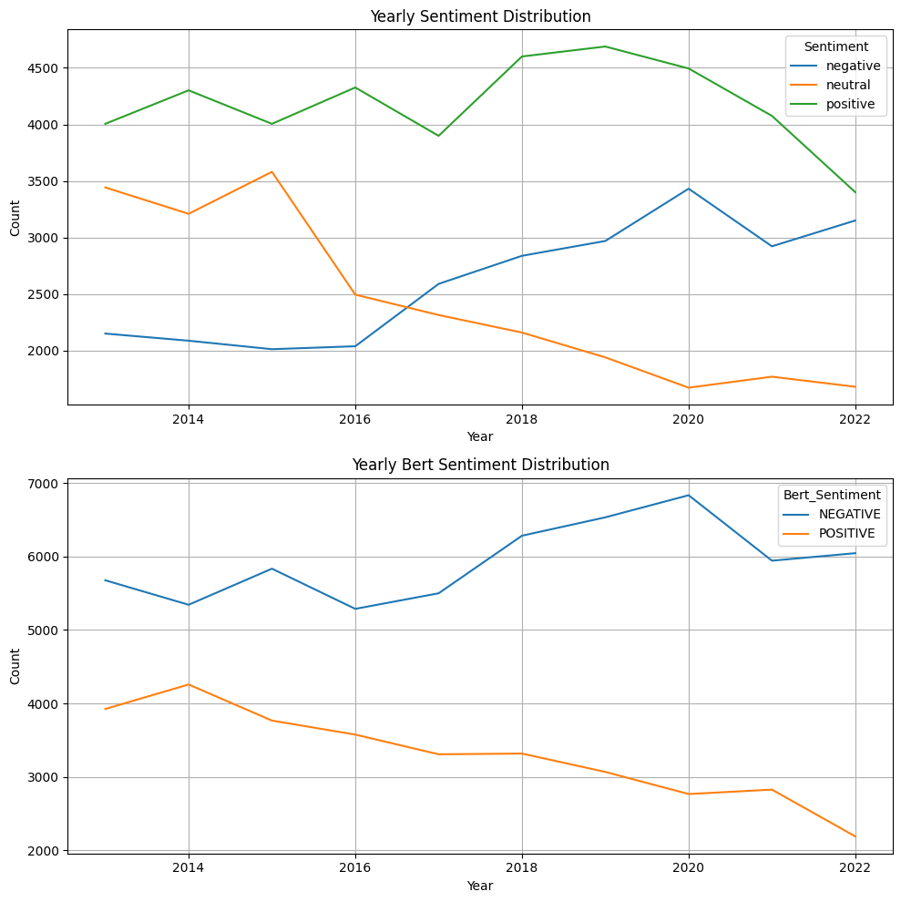

```python
time_series_anlysis_bar_chart(usa_tweets_df)
time_series_analysis_line_chart(usa_tweets_df)
```

#### Wnioski:

- zdecydowanie mniejsza liczba tweetów o neutralnym chrakterze niż w przypadku Chin
- od 2015 zmniejsza się liczba neutralnych tweetów
- od 2016 do 2020 roku (pierwsza kadencja Trumpa?) wzrosła liczba negatywnych tweetów, ale spadła ona w 2021 roku (moderacja związana z pandemią?). Te wzrosty i spadki były jednak mniejsze niż w przypadku Chin

### Bibliografia

https://www.datacamp.com/tutorial/text-analytics-beginners-nltk  
https://huggingface.co/transformers/v3.0.2/main_classes/pipelines.html